# 1 Display the Game

#### 1.2.2.4 The Bishop

The *Bishop* can move any distance along the diagonals, on which it is placed, unless its way is blocked by another piece:

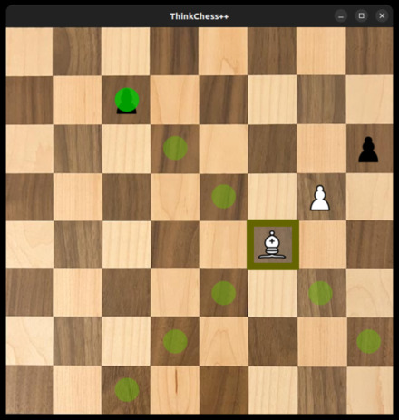

Notice, that a bishop, placed initially on a light field, will always stay on a light field, and vice versa. Thus, both players each have a *dark* and a *light* bishop (the white bishop on `f4` is a *dark* bishop with its initial position on `c1`). Dark and light bishops can never attack each other.

We use essentially the same logic as for the rook, but this time we check for pieces on the same diagonal:

```cpp
bool Bishop::isValid(const vector<vector<Piece*>>& bd, int r, int c) {
  bool valid = r-c == row-col || r+c == row+col;
  if (r-c == row-col) { // same major diagonal
    if (r < row) { // upper
      for (int rr = row-1; rr > r; rr--) {
        for (int cc = col-1; cc > c; cc--) {
          if (rr-cc == row-col) {
            auto pc = bd[rr][cc];
            if (pc) { valid = false; break; }
          }
        }
      }
    } else { // lower
      for (int rr = row+1; rr < r; rr++) {
        for (int cc = col+1; cc < c; cc++) {
          if (rr-cc == row-col) {
            auto pc = bd[rr][cc];
            if (pc) { valid = false; break; }
          }
        }
      }
    }
  }
  if (r+c == row+col) { // same minor diagonal
    if (r < row) { // upper
      for (int rr = row-1; rr > r; rr--) {
        for (int cc = col+1; cc < c; cc++) {
          if (rr+cc == row+col) {
            auto pc = bd[rr][cc];
            if (pc) { valid = false; break; }
          }
        }
      }
    } else { // lower
      for (int rr = row+1; rr < r; rr++) {
        for (int cc = col-1; cc > c; cc--) {
          if (rr+cc == row+col) {
            auto pc = bd[rr][cc];
            if (pc) { valid = false; break; }
          }
        }
      }
    }
  }
  return valid;
}
```

Here, we also have four searches: two for the major diagonal and another two for the minor diagonal. The searches are now nested loops, as we need to get both coordinates for the current field.

There are at most $6 × 6 = 36$ tests per search, and on average only $3 × 3 = 9$ tests for each. And, as before, only one of these searches will ever by executed for any given field. So, we may consider these searches as *constant time* searches as well.

#### 1.2.2.5 The Queen

The *Queen* can move any distance in all directions (on its rank, file or diagonals), only limited by other pieces in its way. In the image below you can see, why the queen is the strongest piece on the board:

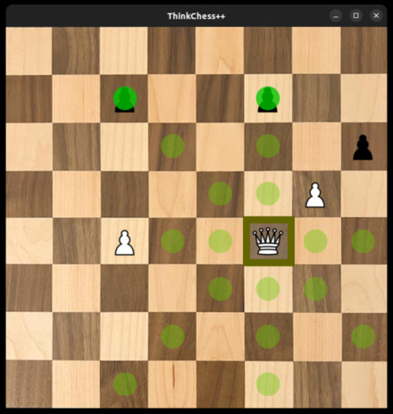

We use a little trick to get the queens valid moves: as the queen can move like a rook *and* a bishop, we just check for valid moves for *either* of them:

```cpp
bool Queen::isValid(const vector<vector<Piece*>>& bd, int r, int c) {
  auto rook = new Rook(white, row, col);
  auto bishop = new Bishop(white, row, col);
  bool valid = rook->isValid(bd, r, c) || bishop->isValid(bd, r, c);
  delete rook;
  delete bishop;
  return valid;
}
```

Observe that we have to delete those dummy pieces, in order to prevent any memory leaks.

#### 1.2.2.6 The Pawn

The last piece to cover is the *Pawn*: it is the weakest piece on the board, but in exchange, both players have 8 of them. The movement of the pawns is the most complex of all pieces:

- **base case**: move straight forward one square on its file, if that square is vacant
- **capturing**: capture an opponents piece on either of the two squares diagonally in front of it
- **initial position**: if the pawn has not yet moved, it has the option of moving two squares straight forward, provided both squares are vacant.

Notice that the terms *forward* and *in front* always refer to the direction towards the opponents pieces: the *white* pawns moves to the higher ranks (e.g. `e2-e4`), while the *black* pawns move towards the lower ranks (e.g. `d3xe2`).

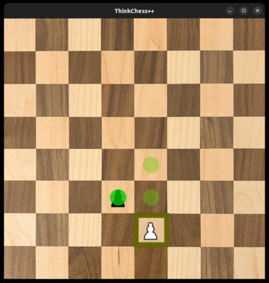

There are also two special moves involving pawns, called *en passant* and *promotion*, which we will cover in special moves.

Here’s the code to put the rules in action:

```cpp
bool Pawn::isValid(const vector<vector<Piece*>>& bd, int r, int c) {
  bool valid = false;
  auto pc = bd[r][c];
  if (white) {
    if (r == row-1 && c == col) { // move
      if (!pc) valid = true;
    }
    if (row == 6 && r == 4 && c == col) { // initial move
      auto pc1 = bd[5][c];
      if (!pc1 && !pc) valid = true;
    }
    if (r == row-1 && (c == col-1 || c == col+1)) { // capture
      if (pc && pc->isWhite() != white) valid = true;
    }
  } else { // black
    if (r == row+1 && c == col) { // move
      if (!pc) valid = true;
    }
    if (row == 1 && r == 3 && c == col) { // initial move
      auto pc1 = bd[2][c];
      if (!pc1 && !pc) valid = true;
    }
    if (r == row+1 && (c == col-1 || c == col+1)) { // capture
      if (pc && pc->isWhite() != white) valid = true;
    }
  }
  return valid;
}
```

# 2 Play the Game

Now that we have a board with the pieces on it, we actually want to play the game.

To that goal, we will explore how to make moves and store them for later usage.

Finally, we will consider special moves and positions to improve the game play.

## 2.1 Making Moves

The first thing we need for making moves, is a way to process user input. We’ll do that inside the event loop of the main function:

```cpp
// mouse button pressed
if (event.type == sf::Event::MouseButtonPressed) {
  if (event.mouseButton.button == sf::Mouse::Left) {
    pair<int, int> f = getField(event.mouseButton.x,
                                event.mouseButton.y);
    if (touched.first == -1) touched = f;
    else if (f == touched) touched = {-1, -1};
  }
}
// mouse button released
if (event.type == sf::Event::MouseButtonReleased) {
  if (event.mouseButton.button == sf::Mouse::Left) {
    pair<int, int> f = getField(event.mouseButton.x,
                                event.mouseButton.y);
    if (touched.first != -1 && touched != f)
      makeMove(board, moves, captured, touched, f, player);
  }
}

// get board coordinates
pair<int, int> getField(int x, int y) {
  int fx = x / 80;
  int fy = y / 80;
  auto field = make_pair(fy, fx);
  return field;
}
```

We’re using the *left* mouse button for making moves (3, 12); remember that we’ve used the right button for showing valid moves.

First, we need the coordinates of the board, where the mouse button was pressed (4), respectively released (13).  
When *pressing* the button, and no field was touched yet (6), we set the variable `pair<int,int> touched` to those coordinates. But if a field was already touched, and it’s the current field, we reset `touched` (7).

When *releasing* the button, we check wether a field was touched (15), and if it’s not the current field, we make a move from the touched to the current field (16).

With this mechanism, we can make a move in two ways:

- *drag-and-drop*: just move a piece from its current position to the target, while holding the left mouse button
- *click twice*: click once on the piece to move, and a second time on the target field.

The `getField()` function (21-26) converts the coordinates of the mouse cursor to the coordinates of the board matrix. Observe that it returns the coordinates in that order: first the row index, second the column index.

In order to clean up the design, I decided to do some refactorings: I moved all function definitions, except the main function, to a separate implementation file `app/moves.cpp`; and I moved all variable definitions into the main function, to get rid of global variables.

So, we’ll have the following definitions inside the main function:

```cpp
// matrix of pieces representing the board
vector<vector<Piece*>> board(8, vector<Piece*>(8));

// matrix of valid moves for display
vector<vector<short>> validMoves(8, vector<short>(8, 0));

// list of moves, used as a stack
auto* moves = new list::List<string>;

// list of captured pieces, used as a stack
auto* captured = new list::List<Piece*>;

// touched field for making moves
pair<int, int> touched{-1, -1};

// player to turn, starting with white
bool player = true;
```

The variables `moves` and `captures` are *linked lists*, which I’ve implemented in a separate library called `datastructures` within a namespace `list`. I will not go into details here, but if you are interested in implementing a linked list for yourself, have a look at the file `include/list.hpp` in that directory (it’s quite well documented, so you should find your way around).

But now, to the most important function of this section: `makeMove()`.

```cpp
void makeMove(vector<vector<Piece*>>& bd,
              list::List<string>* mv,
              list::List<Piece*>* cp,
              pair<int, int>& td,
              pair<int, int> to,
              bool& player)
{
  auto pcf = bd[td.first][td.second];
  auto pct = bd[to.first][to.second];
  bool cap = false;
  if (!pcf) {
    cout << "no piece under cursor\n";
    td = {-1, -1};
    return;
  }
  if (pcf->isWhite() != player) {
    cout << "it's not your turn\n";
    td = {-1, -1};
    return;
  }
  if (pcf->isValid(bd, to.first, to.second)) {
    if (pct && pct->isWhite() != pcf->isWhite()) {
      cap = true;
      pct->capture();
      cp->push_front(pct);
    } else if (pct) {
      cout << "illegal move!\n";
      td = {-1, -1};
      return;
    }
    mv->push_front(convertFromBoard(cap, pcf, to));
    bd[to.first][to.second] = pcf;
    bd[td.first][td.second] = nullptr;
    pcf->makeMove(to.first, to.second);
    td = {-1, -1};
    player = !player;
    cout << mv->peek(1) << "\n";
  // illegal move
  } else {
    cout << "illegal move!\n";
    td = {-1, -1};
  }
}
```

First, we get the pieces of the start (`td`, the touched field) and target coordinates (`to`) of the move(8, 9).  
If there’s no piece at the start coordinates (11), reset the touched field (13) and abort the move (14).  
If the color of the start piece doesn’t match the player, whose turn it is (16), also abort the move (19).

Otherwise, check wether the move is valid (21), and wether the piece at the target position can be captured (22).  
If so, capture the piece (24) and push it onto the stack of captured pieces (25). Otherwise, if there’s a piece of the same color (26), abort the move (29).

So far, we’ve checked all the possible variations and have a valid move; thus, we add the move to the stack of moves (31). Then, we set the piece under the cursor to its target position on the board (32), overwriting the old reference, and delete its old position (33).

Finally, we tell the piece its new position (34), reset the touched field (35), and switch to the other player (36).

For pushing the move onto the moves stack, I used a function `convertFromBoard` (31), which is defined like so:

```cpp
string convertFromBoard(bool cap, Piece* from, pair<int, int> to) {
  string move;
  char type = from->getType();
  if (type != 'P') {
    move.append(1, type);
  }
  move.append(1, colToFile(from->getCol()));
  move.append(1, rowToRank(from->getRow()));
  if (cap) {
    move.append(1, 'x');
  } else {
    move.append(1, '-');
  }
  move.append(1, colToFile(to.second));
  move.append(1, rowToRank(to.first));
  return move;
}

char colToFile(int col) {
  char file = 97 + col;
  return file;
}

char rowToRank(int row) {
  char rank = 56 - row;
  return rank;
}
```

The function takes a piece (`from`) and target coordinates (`to`) as parameters, and converts them into a string of algebraic chessnotation. It makes use of two helper functions `colToFile()` and `rowToRank()`, which convert the coordinates of the board matrix to chess coordinates.

Those functions use a little trick, based on the specification of the `char` type in C<sup>++</sup>: the actual value of a character is stored as a `short int`, based on the ascii code for that character. So, the letter ‘a’ is stored internally as 97, and the digit ‘8’ as 56. We use this fact for a simple calculation.

The only thing left to do is to adjust the `resetBoard()` function to take care of the moves stack and the captured pieces:

```cpp
void resetBoard(vector<vector<Piece*>>& bd,
                 list::List<string>* mv,
                 list::List<Piece*>* cp)
{
  // reset moves and captured pieces
  delete mv;
  mv = new list::List<string>;
  delete cp;
  cp = new list::List<Piece*>;
  // reset board
  for (auto rank : bd) {
    for (auto piece : rank) {
      delete piece;
    }
  }
  // --- snip ---
}
```

We have to explicitly delete the moves stack and the stack of captured pieces when resetting to board, in order to avoid memory leaks. But then, we have to create them again as empty lists, as we want to use them for the next game. Notice, that not only the references to those lists are deleted, but also all elements inside the lists, due to that destructor in the file `datastructures/include/list.hpp`:

```cpp
template<typename T>
class List : public LL<T> {
public:
  ~List() {
    Node* node = head;
    while(node) {
      Node* curr = node;
      node = node->next;
      delete curr;
    }
    delete node;
  }
}
```

The very last thing, we want to do in this section, is to add a marker inside the main function for the touched piece on the board

```cpp
sf::RectangleShape frame(sf::Vector2f(63.f, 60.f));
frame.setFillColor(sf::Color(200, 200, 200, 50));
frame.setOutlineThickness(12.f);
frame.setOutlineColor(sf::Color(100, 100, 0));
```

and draw it together with the pieces inside the game loop:

```cpp
// draw pieces
for (int row = 0; row < 8; row++) {
  for (int col = 0; col < 8; col++) {
    if (board[row][col]) {
      auto piece = board[row][col];
      // --- snip ---
      if (row == touched.first && col == touched.second) {
        frame.setPosition(col*80.f + 10.f, row*80.f + 10.f);
        window.draw(frame);
      }
      pc.setPosition(col*80.f + 10.f, row*80.f + 10.f);
      window.draw(pc);
    }
  }
}
```

## 2.2 Special Positions

### 2.2.1 Check and checkmate

The most prominent position in a game is the check, where the king is under immediate attack. So far, we have no mechanism to respond to or even detect a *check*. Let’s change that now.

For that, we only need to iterate over all opponent pieces, and if any of them can reach the king with a valid move, we have a check:

```cpp
bool check(vector<vector<Piece*>>& bd, bool white) {
  Piece* king;
  bool check = false;
  for (int row = 0; row < 8; row++) {
    for (int col = 0; col < 8; col++) {
      auto current = bd[row][col];
      if (current && current->getType() == 'K' &&
          current->isWhite() == white)
      {
        king = current;
      }
    }
  }
  for (int row = 0; row < 8; row++) {
    for (int col = 0; col < 8; col++) {
      auto current = bd[row][col];
      if (current && current->isWhite() != white) {
        if (current->isValid(bd, king->getRow(), king->getCol())) {
          check = true;
        }
      }
    }
  }
  return check;
}
```

First, iterate over all positions of the board (4-5) and check wether the piece at that position is the king of the given color (7-8). If so, store the position of the king (10).

Then, iterate again over all positions of the board (14-15) and check wether there’s a piece of the opponent color (17). If so, check wether this piece can reach the king with a valid move (18), and if it can, set the position to *check* (19).

With that, we have two searches with 64 tests each, and we need to run them sequentially, resulting in 128 tests. Now you could think that’s superfluous, as we could test only against the piece actually being moved, reducing the second search to a single test. But you would be wrong: a check can be given by any other piece, if a blocking piece is moved. Convince yourself with this diagram:

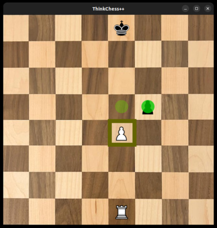

If white captures the black pawn on `f5` with `e4xf5+`, the white rook on the `e`-file will give the black king check.

Now, before making the move, let’s look at the other special (and terminal) position: *checkmate*. If a player, given check in the last move, cannot respond to the check in the very next move, that players king is checkmate, and the game is over.

There are, in general, three ways to get out of check: 1. capturing the checking piece 2. moving the king 3. blocking the check.

It’s the players duty to analyze the position and to find the best solution. For now, our app cannot do this, it’s a quite complex task.

But thankfully, it doesn’t have to: we only want to detect a checkmate and decide wether the game is over at this point. For that, we dont’t need any fancy algorithm or some kind of intelligence, we just use a [brute-force](https://en.wikipedia.org/wiki/Brute-force_search) search. Instead of finding the best solution, we only need to know if there is *any* solution:

```cpp
bool resolveCheck(vector<vector<Piece*>>& bd, bool white) {
  for (int row = 0; row < 8; row++) {
    for (int col = 0; col < 8; col++) {
      auto current = bd[row][col];
      // get every piece of given color
      if (current && current->isWhite() == white) {
        for (int rr = 0; rr < 8; rr++) {
          for (int cc = 0; cc < 8; cc++) {
            if (current->isValid(bd, rr, cc)) {
              auto pct = bd[rr][cc];
              if (!pct || pct->isWhite() != white) {
                // make move and test for check
                bd[rr][cc] = current;
                current->makeMove(rr, cc);
                if (!check(bd, white)) {
                  bd[rr][cc] = pct;
                  current->makeMove(row, col);
                  return true;
                } else {
                  bd[rr][cc] = pct;
                  current->makeMove(row, col);
                }
              }
            }
          }
        }
      }
    }
  }
  return false;
}
```

Iterate over all fields of the board (2-3); if there’s a piece at this position with the color of the checked player (6), start another nested loop (7-8) to get the valid moves of that piece (9). If the reachable fields are empty or the pieces at these positions are of the other color (i.e. they can be captured), make this move by setting the current piece to this position (13-14).

If this new position is not giving check (15), we have a solution and return `true`, indicating that the check could be resolved with that move (18).  
But, before doing so, reset the board to its original state, as we don’t want to actually make the move (16-17).

If the new position still is giving check (19), reset the board as well (20-21) and continue the search.

With that, we have four nested loops with $8 × 8 × 8 × 8 = 64 × 64 = 4096$ tests, which is the cost of *brute search*. But, real work is only done, if we have a piece of the given color (outer nested loops), and if this piece has any valid moves (inner nested loops).  
A player has at most 16 pieces on the board, and assuming that each of them has 3 valid moves on average, the `check` function will be called mo more than 48 times on average. Thus, we may consider that search as of constant time as well.

With all that in place, we can finally make a move, while testing for *check* and *checkmate*:

```cpp
void makeMove(vector<vector<Piece*>>& bd,
              list::List<string>* mv,
              list::List<Piece*>* cp,
              pair<int, int>& td,
              pair<int, int> to,
              bool& player,
              pair<int, int>& checkmate)
{
  auto pcf = bd[td.first][td.second];
  auto pct = bd[to.first][to.second];
  bool cap = false;
  if (!pcf) {
    cout << "no piece under cursor\n";
    td = {-1, -1};
    return;
  }
  if (pcf->isWhite() != player) {
    cout << "it's not your turn\n";
    td = {-1, -1};
    return;
  }
  // valid move?
  if (pcf->isValid(bd, to.first, to.second)) {
    // can capture?
    if (pct && pct->isWhite() != pcf->isWhite()) {
      cap = true;
      cp->push_front(pct);
    } else if (pct) { // same color
      cout << "illegal move!\n";
      td = {-1, -1};
      return;
    }
    // legal move
    string move = convertFromBoard(cap, pcf, to);
    bd[to.first][to.second] = pcf;
    bd[td.first][td.second] = nullptr;
    pcf->makeMove(to.first, to.second);
    // check?
    if (check(bd, player)) { // gives itself check
      cout << "illegal move!\n";
      bd[to.first][to.second] = pct;
      bd[td.first][td.second] = pcf;
      pcf->makeMove(td.first, td.second);
      td = {-1, -1};
      return;
    }
    if (check(bd, !player)) { // gives opponent check
      if (resolveCheck(bd, !player)) {
        move.append(1, '+');
      } else { // cannot get out of check
        move.append(1, '#');
        mv->push_front(move);
        cout << mv->peek(1) << "\n";
        checkmate = getKing(bd, !player);
        return;
      }
    }
    mv->push_front(move);
    cout << mv->peek(1) << "\n";
    td = {-1, -1};
    player = !player;
  // illegal move
  } else {
    cout << "illegal move!\n";
    td = {-1, -1};
  }
}
```

We have an extra parameter `pair<int, int>& checkmate` for keeping track of *checkmate*. Besides, There’s nothing new in lines (1-37).

Then test, wether the move gives the own king check (39), and if it does, abort the move (44-45), as this is not allowed.  
But, before that, reset the already made move (41-43). Notice, that we had to make the move in the first place in order to allow the test for check.

If the move gives the opponents king check (47), test wether the check could possibly be resolved (48), and if so, add the marker ‘+’ to the move (indicating check, 49).  
If the check cannot be resolved (50), add the marker ‘#’ to the move (indicating checkmate, 51), push the move to the moves stack (52), and set the `checkmate` variable to the position of the checkmated king (54).  
Then, proceed as before (58-67).

The only thing missing, is the implementation of the `getKing` function on line 54. It’s essentially the same as the first loop of the `check` function, but only returning the coordinates of the king. Try to implement that function for yourself; if you get stuck, check my implementation in the file `app/moves.cpp`.

We use the `checkmate` variable to to stop the game and draw a corresponding marker on the board within the main function of the app:

```cpp
short state = 1;
pair<int, int> checkmate{-1, -1};

//marker for checkmate
sf::RectangleShape cm(sf::Vector2f(63.f, 60.f));
cm.setFillColor(sf::Color(200, 200, 200, 50));
cm.setOutlineThickness(12.f);
cm.setOutlineColor(sf::Color(200, 0, 0));

// game loop
while (window.isOpen()) {
  // event loop
  for (auto event = sf::Event{}; window.pollEvent(event);) {
    if (event.type == sf::Event::Closed) {
      window.close();
    }
    // game is running in play mode
    if (state == 1) {
      // mouse button pressed
      if (event.type == sf::Event::MouseButtonPressed) {
        if (event.mouseButton.button == sf::Mouse::Right) {
          pair<int, int> f =
            getField(event.mouseButton.x, event.mouseButton.y);
          setValidMoves(board, validMoves, board[f.first][f.second]);
        }
        if (event.mouseButton.button == sf::Mouse::Left) {
          pair<int, int> f =
            getField(event.mouseButton.x, event.mouseButton.y);
          if (touched.first == -1) touched = f;
          else if (f == touched) touched = {-1, -1};
        }
      }
      // mouse button released
      if (event.type == sf::Event::MouseButtonReleased) {
        if (event.mouseButton.button == sf::Mouse::Right) {
          validMoves = vector<vector<short>>(8, vector<short>(8, 0));
        }
        if (event.mouseButton.button == sf::Mouse::Left) {
          pair<int, int> f =
            getField(event.mouseButton.x, event.mouseButton.y);
          if (touched.first != -1 && touched != f)
            makeMove(board, moves, captured, touched,
                     f, player, checkmate);
        }
      }
    } // end play mode
  } // end event loop

  // draw pieces
  for (int row = 0; row < 8; row++) {
    for (int col = 0; col < 8; col++) {
      if (board[row][col]) {
        // --- snip ---
        if (row == checkmate.first && col == checkmate.second) {
          cm.setPosition(col*80.f + 10.f, row*80.f + 10.f);
          window.draw(cm);
        }
        pc.setPosition(col*80.f + 10.f, row*80.f + 10.f);
        window.draw(pc);
      }
    }
  }
  // display frame
  window.display();

  // stop game when checkmate
  if (checkmate.first != -1) state = 0;
}
```

And here you have it: a fully playable chess app for two players!

Playing the moves

```
1. e2-e4 e7-e5
2. Ng1-f3 Ng8-f6
3. Nf3xe5 Nf6xe4
4. Qd1-f3 Ne4-c5
5. Qf3xf7#
```

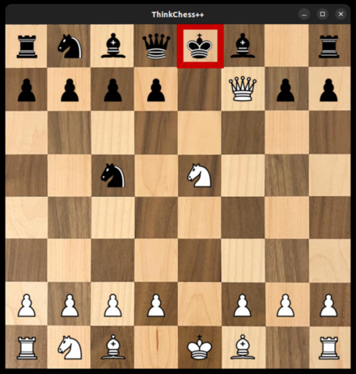

### 2.2.2 Stalemate

Stalemate is a situation in chess where the player, whose turn it is to move, is not in check but has no legal move. Stalemate immediately results in a draw (i.e. the game is over and both players are credited half a point). During the endgame, stalemate is a resource that can enable the player with the inferior position to draw the game rather than lose.

Stalemate is much harder to detect than checkmate: as the king has not been given check, we cannot use our `check` and `resolveCheck` functions for this position. Of course, we could try to do something similar, but only with a much higher expense. But, as stalemates are actually much rarer than checkmates, I decided to not spend this effort for now.

So, when playing a game with the app, both players have to agree to stalemate (and with that to a draw), like they would have to in a tournament.

## 2.3 Special Moves

To complete this chapter, we will now implement the missing *special* moves for

- the king: [castling](https://en.wikipedia.org/wiki/Castling)
- the pawns: [en passant](https://en.wikipedia.org/wiki/En_passant) and promotion.

### 2.3.1 Castling

Castling is the only move, in which two pieces are moved at once (the king and one of the rooks of the same color). The king moves two squares towards a rook on the same rank and the rook moves to the square that the king passed over.

Castling is permitted only if - neither the king nor the rook has previously moved - the squares between the king and the rook are vacant - the king does not leave, cross over, or finish on a square attacked by an enemy piece.

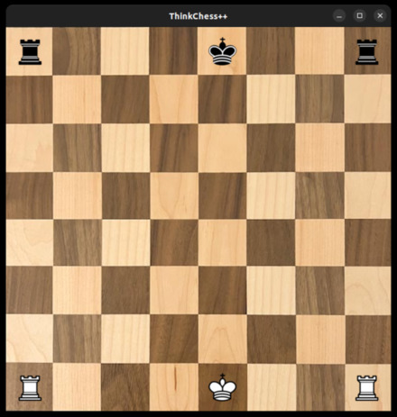

Assuming in the diagram above, that neither of the players has castled yet, they could move like so:

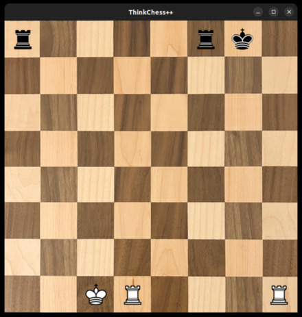

White has castled to the queenside (indicated with `0-0-0`), while black has castled to the kingside (indicated with `0-0`).

We implement the logic for *castling* with a function called `castling`:

```cpp
char castling(vector<vector<Piece*>>& bd,
              Piece* king, pair<int, int> to)
{
  if (check(bd, king->isWhite())) return 'N'; // king is in check
  if (king->isWhite()) { // white
    if (king->getRow() == 7 && king->getCol() == 4) {
      // TODO: king has moved
      if (to.first == 7 && to.second == 6) { // kingside
        auto rook = bd[7][7];
        if (!rook || rook->getType() != 'R'
                  || rook->isWhite() != king->isWhite()) {
          // TODO: rook has moved
          return 'N';
        }
        auto pc1 = bd[7][5];
        auto pc2 = bd[7][6];
        if (pc1 || pc2) return 'N'; // fields occupied
        else {
          // test for check
          bd[7][5] = king;
          king->makeMove(7, 5);
          if (check(bd, king->isWhite())) {
            bd[7][4] = king;
            king->makeMove(7, 4);
            bd[7][5] = nullptr;
            return 'N';
          } else {
            bd[7][4] = king;
            king->makeMove(7, 4);
            bd[7][5] = nullptr;
          }
          bd[7][6] = king;
          king->makeMove(7, 6);
          if (check(bd, king->isWhite())) {
            bd[7][4] = king;
            king->makeMove(7, 4);
            bd[7][6] = nullptr;
            return 'N';
          } else {
            bd[7][4] = king;
            king->makeMove(7, 4);
            bd[7][6] = nullptr;
          }
          return 'K';
        }
      } else if (to.first == 7 && to.second == 2) {
      // --- snip queenside ---
      }
    }
  } else {
  // --- snip black ---
  }
  return 'N';
}
```

First, test wether the king is currently in check, and if so, abort with negative result (4).  
Then, test for the white king (5): we have to test the kings separately, as they sit on different ranks.

Next, test wether the king is on its initial position (6). Observe, that for now, this test is not complete: the king could have moved from and back to its initial position. Since we will learn to process stored moves only in the next chapter, there is no way to complete the test for now. But we must not forget to make this right, so I’ve left a `TODO` comment here.

Next, test for kingside castling (8):  
if there’s no rook of the same color on its initial position (10-11), abort with negative result (13). Observe, that we have the same issue as with the king before, so I’ve added a `TODO` marker as well.

Then, test wether the fields between the king and the rook are occupied (17), and if not, continue with the tests for check for these fields (18). For that, we move the king to the first field (20-21) and test for check (22).  
If it is in check, abort with negative result (26), after undoing the king move (23-25), since we don’t want to actually move the king. Otherwise reset the move as well (27-31), and test the second field for check (32-43), following the logic from the first field.

If there are no pieces at both fields, and the king would not be in check at those fields, return positive result `K` for kingside castling (44).

Then, repeat the process for queenside castling (46), and finally both processes for the black king (51). If no valid castling position was found, return negative result (53).

With that, we have a lot of redundant code, only differing in the ranks of the king. Of course, one could write that in a more compact way. But that could lead to an overly clever solution, which would be hard to understand for someone without implicit knowledge of what’s going on, even for your future self. So, I decided to leave the code this way and to make every step explicit.

The compiler won’t care about lengthy code anyway. On the contrary, when optimization is enabled (e.g. with the flag `-O3`), the compiler will create the most efficient machine code possible.

By the way, if you want to compile the project in release mode with optimization enabled, you can call `<cmake .. -DCMAKE_BUILD_TYPE=Release>` from the `build` directory, followed by `<cmake -build .>`.  
This will recompile the whole project, and every time, you call `cmake` after that, the project will be compiled in release mode, unless you decide to delete the build directory and re-create it with `cmake -B build` from the root folder.

Having `castling` in place, we can use it inside our `makeMove` function:

```cpp
// already castled, 0 = no, 1 = white, 2 = black, 3 = both
short castled = 0;

void makeMove(vector<vector<Piece*>>& bd,
              list::List<string>* mv,
              list::List<Piece*>* cp,
              pair<int, int>& td,
              pair<int, int> to,
              bool& player,
              pair<int, int>& checkmate,
              short& castled)
{
  auto pcf = bd[td.first][td.second];
  auto pct = bd[to.first][to.second];
  bool cap = false;
  if (!pcf) {
    cout << "no piece under cursor\n";
    td = {-1, -1};
    return;
  }
  if (pcf->isWhite() != player) {
    cout << "it's not your turn\n";
    td = {-1, -1};
    return;
  }
  // castling
  short cast = player ? 1 : 2;
  if (castled < 3 && castled != cast && pcf->getType() == 'K' && !pct) {
    string move = "";
    char form = castling(bd, pcf, to);
    if (form == 'K') {
      castled = castled > 0 ? 3 : cast;
      move = "0-0";
      // make king move
      bd[td.first][td.second+2] = pcf;
      pcf->makeMove(td.first, td.second+2);
      bd[td.first][td.second] = nullptr;
      // make rook move
      auto rook = bd[td.first][7];
      bd[td.first][td.second+1] = rook;
      rook->makeMove(td.first, td.second+1);
      bd[td.first][7] = nullptr;
      if (check(bd, !player)) { // gives opponent check
        if (resolveCheck(bd, !player)) {
          move.append(1, '+');
        } else { // cannot get out of check
          move.append(1, '#');
          mv->push_front(move);
          cout << mv->peek(1) << "\n";
          checkmate = getKing(bd, !player);
          return;
        }
      }
      // complete move
      mv->push_front(move);
      cout << mv->peek(1) << "\n";
      td = {-1, -1};
      player = !player;
      return;
    } else if (form == 'Q') {
      castled = castled > 0 ? 3 : cast;
      move = "0-0-0";
      // make king move
      bd[td.first][td.second-2] = pcf;
      pcf->makeMove(td.first, td.second-2);
      bd[td.first][td.second] = nullptr;
      // make rook move
      auto rook = bd[td.first][0];
      bd[td.first][td.second-1] = rook;
      rook->makeMove(td.first, td.second-1);
      bd[td.first][0] = nullptr;
      if (check(bd, !player)) { // gives opponent check
        if (resolveCheck(bd, !player)) {
          move.append(1, '+');
        } else { // cannot get out of check
          move.append(1, '#');
          mv->push_front(move);
          cout << mv->peek(1) << "\n";
          checkmate = getKing(bd, !player);
          return;
        }
      }
      // complete move
      mv->push_front(move);
      cout << mv->peek(1) << "\n";
      td = {-1, -1};
      player = !player;
      return;
    } // else do nothing and continue with check for valid move
  }
  // --- snip processing other moves ---
}
```

We have a new variable `castled` inside the main function (2), and a respective parameter in the `makeMove` function (11) for keeping track of castling.

The new part starts on line (27):  
we define a local variable `cast` and set it to the player, whose turn it is. Then we test, wether that player has already castled, and wether the piece to move is a king and the target field is not occupied (28).  
Then, test wether castling is possible for that king (30), and if it’s a kingside castling (31), do the following:

1. indicate, that the player has castled (32)
2. set the correct notation for the move (33)
3. make the king move by setting it 2 fields to the right (35-37)
4. make the rook move by setting it to the left of the king (39-42)
5. test wether the move gives the opponents king check (43)
6. if so, test wether the check could be resolved by the opponent (44)
7. if so, complement the move’s notation with a `+`
8. otherwise, it is checkmate: complete the move and stop the game (46-52)
9. complete the move (55-59)

Then, repeat the steps above for queenside castling (60-89). I’ve left out the subsequent code, as it does not differ from the previous version.

With that, we can perform (almost) correct castling for both players; we’ll revisit the code for the `castling` method in the next chapter.

### 2.3.2 Promotion

Promotion is the replacement of a pawn with a new piece when the pawn is moved to its last rank. The player replaces the pawn immediately with a queen, rook, bishop, or knight of the same color. The new piece does not have to be a previously captured piece.

Promotion is almost always to a queen (a.k.a *queening*), as it is the most powerful piece. Since we don’t have a sufficient GUI yet (so the player cannot choose a different piece), we will restrict promotion to queening for now.

With that restriction, it is quite easy to implement promotion inside our `makeMove` function:

```cpp
// valid move?
if (pcf->isValid(bd, to.first, to.second)) {
  // can capture?
  if (pct && pct->isWhite() != pcf->isWhite()) {
    cap = true;
    cp->push_front(pct);
  } else if (pct) { // same color
    cout << "illegal move!\n";
    td = {-1, -1};
    return;
  }

  string move = convertFromBoard(cap, pcf, to);

  // promotion
  if (pcf && pcf->getType() == 'P') {
    if (pcf->isWhite() && pcf->getRow() == 1) { // white
      pcf = new Queen(1, pcf->getRow(), pcf->getCol());
      move.append("=Q");
    } else if (!pcf->isWhite() && pcf->getRow() == 6) { // black
      pcf = new Queen(0, pcf->getRow(), pcf->getCol());
      move.append("=Q");
    }
  } // end promotion

  // legal move
  bd[to.first][to.second] = pcf;
  bd[td.first][td.second] = nullptr;
  pcf->makeMove(to.first, to.second);
}
```

We have to put the new code (15-24) inside the check for valid moves, just before making the move (27-29).

The code tests wether the piece to move is a pawn (16), and wether it is currently placed on the last but one rank for its color (17, 20). If so, the pawn is simply replaced with a queen of the same color (18, 21) and the moves notation is completed accordingly (19, 22).

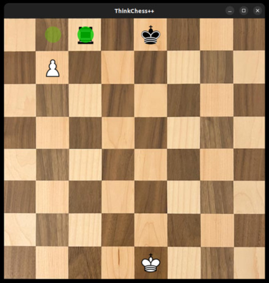

When the pawn on `b7` captures the rook on `c8` in the diagram above, our app will promote the pawn to a queen and also detects the check, reporting this move: `b7xc8=Q+`.

### 2.3.3 En passant

The last special move, we want to cover, is a pawns move called [en passant](https://en.wikipedia.org/wiki/En_passant).

The move describes the capture by a pawn of an enemy pawn on the same rank and an adjacent file, that has just made an initial two-square advance. The capturing pawn moves to the square that the enemy pawn passed over, as if the enemy pawn had advanced only one square.

The rule ensures that a pawn cannot use its two-square move to safely skip past an enemy pawn.

But, since capturing *en passant* is permitted only on the turn immediately after the two-square advance, we would need to investigate the moves history for this. As we have no means to do that for now, we’ll implement that move only in a later chapter, marking it with `TODO` in the meanwhile.

## 2.4 Showing valid moves (revisited)

In valid moves we learned how to show the valid moves for any piece, by pressing the right mouse button on it.

So far, this will only display the valid moves in general, ignoring special positions and special moves.

So, we will not see the moves for castling when clicking on a king, but we’ll see moves, which are not allowed in the current position (whenever the move would give check to the own king).

We could certainly resolve this, but this would also mean a major redesign of our display logic, and would not bear any other benefits for the current game behavior. So I decided, to leave it as it is for now.

On the bright side, this behavior has a positive didactic effect for learners: if you want to make a move, shown as valid, and the app refuses that move (for good reasons), you have to analyze the position for yourself and find the reason why. In most of theses cases, you’d have missed a given check.

# 3 Enhancing the GUI

In this chapter we’ll add a dashboard to our app, including

- a *timer* for keeping track of the player’s thinking time
- an indicator for *material evaluation*
- the display of *captured pieces* for each player
- a *move indicator* for the last move
- a display for the complete *moves history*, and
- an *info field* for displaying messages from the app.

We will also store the current game to a text-file for later use, and add a splash-screen, allowing to display the result of a game and to switch the game mode.

Furthermore, we will give a player the option to take back a move, to offer a draw, and to resign.

Finally, we’ll revisit some *special moves*.

With all that in place, our app will look like so:

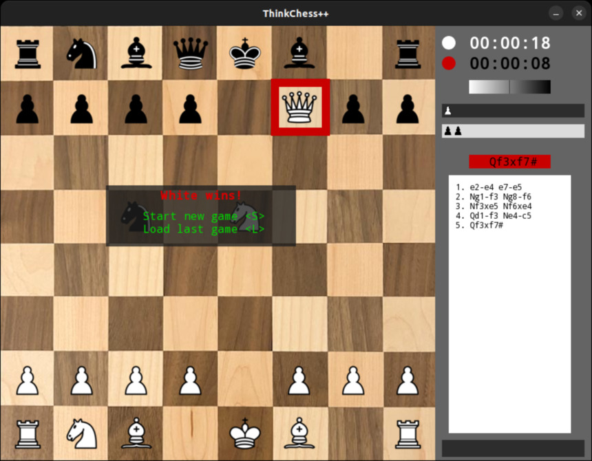

## 3.1 Refactoring

First of all, I created a new translation unit at `app/display.cpp` and its header file at `include/display.hpp`, which will contain all the display-oriented logic.

Next, I created another new unit at `app/position.cpp` and its header file at  
`include/position.hpp` which contains all the move-oriented logic.  
I moved all the functions from the old file `app/moves.cpp` to this new file and deleted the old file.

This new file contains a new type `Position`, which holds all the position-relevant variables, so I could delete those from the `main()` function.

```cpp
class Position {
public:
  ~Position() {}
  Position(short gs) : gamestate{gs}, player{true},
               board{8, vector<Piece*>(8)},
               mvCount{0}, castled{0}, checkmate{-1, -1},
               checked{false}, eval{0.f}
  {}

  // returns a material evaluation for both players
  void evaluate();

  // take back last move
  bool takeBackMove();

  // make a move
  bool makeMove(pair<int, int> from, pair<int, int> to);

  // gamestate: 0 = game over, 1 = 2-player, 2 = analyze
  short gamestate;

  // player on turn, starting with white
  bool player;

  // matrix of pieces representing the board
  vector<vector<Piece*>> board;

  // vector of moves, used as a stack
  vector<string> moves;

  // list of captured pieces, used as a stack
  vector<Piece*> captured;

  // total count of moves
  int mvCount;

  // castled: 0 = no, 1 = white, 2 = black, 3 = both
  short castled;

  // coordinates of the piece, which gave checkmate
  std::pair<int, int> checkmate;

  // last move gave check
  bool checked;

  // basic evaluation of positions
  float eval;

  // infotext
  string info;
};
```

Observe, that I’ve made all the member types public, in order to avoid creating all the associated *getter* and *setter* functions. This would not be a good design decision, if we were to create a library, which was intended to be used by different clients, as those clients could harm the game logic. But, in our case, the only client is the `main()` function of our app, and I suppose that we know what we are doing.

With the new type `Position` in place, we can initialize all relevant variables with a single call from inside the main function: `Position position(0)` and call the `makeMove` function with just two parameters (which are the field coordinates from the board) like so: `position.makeMove(touched, to)`.

Finally, I extended the viewport of the app and made it not resizable:

```cpp
auto window = sf::RenderWindow{ {870, 640u},
                                "ThinkChess++",
                                sf::Style::Close,
                                settings };

window.clear(sf::Color(100, 100, 100));
```

The last line just sets the background of the display area to gray (inside the game loop).

## 3.2 Timer

For displaying the *timer*, we first have to include the `chrono` library and define two time counters, as well as two time points:

```cpp
#include <chrono>
using namespace chrono;

unsigned wTime = 0;
unsigned bTime = 0;
steady_clock::time_point last;
last = steady_clock::now();
steady_clock::time_point now;
```

For calculating the current thinking time for both player, we have this code inside the game loop, just before drawing anything:

```cpp
if (position.gamestate == 1) {
  now = steady_clock::now();
  if (now - last > 1s) {
    last = steady_clock::now();
    if (position.player) wTime++;
    else bTime++;
  }
}
```

The code checks, wether we are in playing mode (gamestate is set to 1), and captures the current time point (2).  
If the difference between `now` and `last` is greater than one second (3), increase the time counter for the player whose turn it is (5-6). Remember, we have set the `sf::FramerateLimit` to 10, so this code will be called 10 times per second, and we cannot simply increase the time counters for each pass.

In order to actually draw the timer, we have this code inside the game loop (directly after the last code snippet):

```cpp
string timer = "";
if (position.player) {
  window.draw(wActive);
  timer = getTime(wTime);
  wTimer.setString(timer);
} else {
  window.draw(bActive);
  timer = getTime(bTime);
  bTimer.setString(timer);
}
if (position.checkmate.first != -1) {
  if (position.player) {
    bActive.setFillColor(sf::Color(200, 0, 0));
    window.draw(bActive);
  } else {
    wActive.setFillColor(sf::Color(200, 0, 0));
    window.draw(wActive);
  }
}
window.draw(wTimer);
window.draw(bTimer);
```

This code also draws the indicator for the active player (the white or black circle in front of the timer) in lines 3 and 7. If the app has detected a checkmate (11), the active player’s indicator is set to a red color (13, 16).

For that to work, we need to have the respective `sf::Sprite`s to be defined (before entering the game loop):

```cpp
// set timer
sf::Text wTimer;
wTimer.setFont(noto);
wTimer.setCharacterSize(24);
wTimer.setStyle(sf::Text::Bold);
wTimer.setFillColor(sf::Color::White);
wTimer.setString("00:00:00");
wTimer.setPosition(690.f, 10.f);

sf::Text bTimer = wTimer;
bTimer.setFillColor(sf::Color::Black);
bTimer.setPosition(690.f, 40.f);

// marker for aktive player
sf::CircleShape wActive(10.f);
wActive.setPosition(650.f, 15.f);
wActive.setFillColor(sf::Color::White);

sf::CircleShape bActive(10.f);
bActive.setPosition(650.f, 45.f);
bActive.setFillColor(sf::Color::Black);
```

In order to display text with SFML, we have to set a font to the `sf::Text` sprite (3), and we also must have a font already in place (just before the last snippet):

```cpp
sf::Font noto;
if (!noto.loadFromFile("../img/NotoMono-Regular.ttf")) {
  cout << "failed to load the font\n";
  return 1;
}
```

I have chosen the *NotoMono-Regular* font, because it is a fixed-space font and quite compact: it only contains 897 glyphs (the images for actually drawing each character), in contrast to more than 5,000 glyphs for fancier fonts.

The last thing missing is the function `getTime()` to convert a time counter (an unsigned integer value) into a readable time format. This function is located inside the new `app/display.cpp` implementation file:

```cpp
string getTime(unsigned t) {
  string result = "";
  unsigned h = 0;
  unsigned m = t / 60;
  unsigned s = t % 60;
  if (m >= 60) {
    h = m / 60;
    m = m % 60;
  }
  if (h < 10) {
    result.append(1, '0');
    result.append(to_string(h));
  } else {
    result.append(to_string(h));
  }
  result.append(1, ':');
  if (m < 10) {
    result.append(1, '0');
    result.append(to_string(m));
  } else {
    result.append(to_string(m));
  }
  result.append(1, ':');
  if (s < 10) {
    result.append(1, '0');
    result.append(to_string(s));
  } else {
    result.append(to_string(s));
  }
  return result;
}
```

The logic is straight forward:  
just divide the total amount of seconds by 60 to get the minutes (4), and take the remainder of that calculation to get the remaining seconds (5).  
If the resulting minutes are greater than 60 (6), repeat those steps to get the hours and remaining minutes (7-8).  
The rest of the code (10-29) is just for formatting: if hours, minutes, and seconds are less than 10, insert the digit `0` at the appropriate position.

## 3.3 Material evaluation

*Material evaluation* is the first step in evaluating the players positions on the board.

Evaluating positions is a complex task, for which one must have a deeper understanding of several factors, including the pawn structure, control of the center, space and initiative. We’ll explore the basics of position evaluation in the next chapter, which will also be the first chapter mainly about *playing* chess.

For now, we are only interested in the first part of this process, which is straight forward: add up the values of the pieces of each player and compare them.

For that we need a new function, which needs access to the board; so it’s a natural choice to define it as a member of the type `Position`:

```cpp
void evaluate() {
  pair<int, int> matEval = evaluateBoard(board);
  eval = float(matEval.first) / 100
       - float(matEval.second) / 100;
}
```

The function calls a helper function, which is defined in the corresponding implementation file:

```cpp
pair<int, int> evaluateBoard(const vector<vector<Piece*>>& bd) {
  int white = 0;
  int black = 0;

  for (int row = 0; row < 8; row++) {
    for (int col = 0; col < 8; col++) {
      auto pc = bd[row][col];
      if (pc) {
        pc->isWhite() ? white += pc->getValue()
                      : black += pc->getValue();
      }
    }
  }
  pair<int, int> eval = make_pair(white, black);
  return eval;
}
```

Observe my design choice: I defined all functions, which need a reference to the board, but will not modify it, as helper functions outside the class `Position`, and I made the reference to the board `const`. So the compiler will ensure that indeed no updates to the board will happen inside those functions.

I also decided to slightly modify the value scheme for pieces of section pieces: the queen now has a value of 9, and the rooks each a value of 5. To be able to do more accurate calculations later, the values are defined as *centipawns* by multiplying them with 100. With that, we’ll be able to make all future calculations on the base of integer values, which should be faster than calculating with `float` representations of the value.

The current implementations of the pieces look like so:

```cpp
class Queen : public Piece {
public:
  ~Queen() {}
  Queen(bool w, int r, int c) :
    type{'Q'}, white{w}, value{900}, row{r}, col{c} {}

  char getType() override { return type; }
  int getValue() override { return value; }
  bool isWhite() override { return white; }
  int getRow() override { return row; }
  int getCol() override { return col; }
  void makeMove(int r, int c) override { row = r; col = c; }
  bool isValid(const vector<vector<Piece*>>& bd, int r, int c) override;

private:
  char type;
  bool white;
  int value;
  int row;
  int col;
};
```

Now we can use the evaluation function inside the game loop to actually draw the *evaluation meter*:

```cpp
if (moved) {
  if (position.mvCount % 2 == 0) {
    position.evaluate();
    eval = position.eval;
    if (eval > 10.0) {
      eval = 10.f;
      mb[2].color = sf::Color(200, 0, 0, 200);
      mb[4].color = sf::Color(200, 0, 0, 200);
      mb[5].color = sf::Color(200, 0, 0, 200);
    }
    if (eval < -10.0) {
      eval = -10.f;
      mb[0].color = sf::Color(200, 0, 0, 200);
      mb[1].color = sf::Color(200, 0, 0, 200);
      mb[3].color = sf::Color(200, 0, 0, 200);
    }
    mi[2].position = sf::Vector2f(750.f + eval*6.f, 80.f);
    mi[3].position = sf::Vector2f(750.f + eval*6.f, 100.f);
    if (eval > 0) {
      mi[2].color = sf::Color::White;
      mi[3].color = sf::Color::White;
    } else {
      mi[2].color = sf::Color::Black;
      mi[3].color = sf::Color::Black;
    }
  }
}
```

When a move is complete, i.e. both players have moved (2), evaluate the material (3).  
Then, set the local variable `eval` to the calculated value (4); we are doing so, because we don’t want to tinker with the member variables of `Position` from outside the class (remember my caveat for this design decision).  
For display purposes, we restrict that value to the range $[ − 10, 10]$, and set the background color of the evaluation meter to red, if the value is outside that range (5-16).  
Finally, we set the position and the color of the evaluation indicator (17-24). We’ll see soon, how this works.

You may have noticed that this code will only be executed, if a move was made (1). Remember, this code is placed inside the game loop, and we don’t want to evaluate the board for every update of the display. So I modified the `Position::makeMove()` function to report success, and call it like so: `moved = position.makeMove(touched, to)`:

```cpp
bool makeMove(pair<int, int> td, pair<int, int> to) {
  auto pcf = board[td.first][td.second];
  auto pct = board[to.first][to.second];

  if (!pcf) {
    info = "no piece selected";
    return false;
  }
  if (pcf->isWhite() != player) {
    info = "it's not your turn";
    return false;
  }
  // --- snip ---
}
```

The background of the evaluation meter (`mb`) is defined as an SFML primitive (a set of two unconnected triangles), and the evaluation indicator (`mi`) as a set of two unconnected vertical lines:

```cpp
sf::VertexArray mb(sf::Triangles, 6);
mb[0].position = sf::Vector2f(690.f, 80.f);
mb[1].position = sf::Vector2f(690.f, 100.f);
mb[2].position = sf::Vector2f(810.f, 100.f);
mb[3].position = sf::Vector2f(690.f, 80.f);
mb[4].position = sf::Vector2f(810.f, 80.f);
mb[5].position = sf::Vector2f(810.f, 100.f);
mb[0].color = sf::Color::White;
mb[1].color = sf::Color::White;
mb[2].color = sf::Color::Black;
mb[3].color = sf::Color::White;
mb[4].color = sf::Color::Black;
mb[5].color = sf::Color::Black;

sf::VertexArray mi(sf::Lines, 4);
mi[0].position = sf::Vector2f(750.f, 80.f);
mi[1].position = sf::Vector2f(750.f, 100.f);
mi[2].position = sf::Vector2f(750.f, 80.f);
mi[3].position = sf::Vector2f(750.f, 100.f);
mi[0].color = sf::Color::Green;
mi[1].color = sf::Color::Green;
mi[2].color = sf::Color::Black;
mi[3].color = sf::Color::Black;
```

I’ve set the color of the triangle points to black and white, such that the meter’s background color is interpolated to fill the background with a gradient from white to black. The green line of the indicator shows the neutral position (the evaluation value 0) and it’s static. The black line (*m**i*[2] and *m**i*[3]) is the actual indicator, which we have updated when processing a move.

With this setup, the indicator will move to the right when the evaluation value is greater than zero (i.e. white has an advantage), and move to the left when black has an advantage. This may seem counter-intuitive at first, but once you get used to it, you’ll catch the evaluation at a glance.

## 3.4 Captured pieces

For displaying the captured pieces of each player, we only need two background areas:

```cpp
sf::RectangleShape bcw(sf::Vector2f(210.f, 20.f));
bcw.setFillColor(sf::Color(30, 30, 30, 200));
bcw.setPosition(650.f, 115.f);
sf::RectangleShape bcb = bcw;
bcb.setFillColor(sf::Color(220, 220, 220));
bcb.move(0.f, 30.f);
```

and a way to draw miniature versions of the pieces figures onto those:

```cpp
window.draw(bcw);
window.draw(bcb);
int wc = -1;
int bc = -1;
for (auto piece : position.captured) {
  sf::Sprite cp;
  switch (piece->getType()) {
  case 'K':
    piece->isWhite() ? cp = wk : cp = bk;
    break;
  case 'Q':
    piece->isWhite() ? cp = wq : cp = bq;
    break;
  case 'R':
    piece->isWhite() ? cp = wr : cp = br;
    break;
  case 'B':
    piece->isWhite() ? cp = wb : cp = bb;
    break;
  case 'N':
    piece->isWhite() ? cp = wn : cp = bn;
    break;
  case 'P':
    piece->isWhite() ? cp = wp : cp = bp;
    break;
  }
  cp.scale(0.3f, 0.3f);
  if (piece->isWhite()) {
    wc++;
    cp.setPosition(650.f + wc*15.f, 115.f);
  } else {
    bc++;
    cp.setPosition(650.f + bc*15.f, 145.f);
  }
  window.draw(cp);
}
```

Getting the captured pieces is easy, as we had already stored them in a separate data structure `captured` within the `position` object, while making a move:

```cpp
// valid move?
if (pcf->isValid(board, to.first, to.second)) {
  // can capture?
  if (pct && pct->isWhite() != pcf->isWhite()) {
    cap = true;
    captured.push_back(pct);
  } else if (pct) { // same color
    info = "illegal move";
    return false;
  }
  // --- snip ---
}
```

I’ve rejected the idea of storing the captures pieces in a linked list; instead, I’m using a vector of pieces: `vector<Piece*>`. We can easily use a vector as a *stack* (a *LIFO* data structure) by using its member functions `push_back()` and `pop_back()` in a very performant way. Additionally, vectors provide an iterator, which we can use in the *range-for* statement `for (auto piece : position.captured)`, without actually *popping* the elements.

## 3.5 Move indicator

The *move indicator* is implemented with a similar pattern:

```cpp
// current move background
sf::RectangleShape mvb(sf::Vector2f(120.f, 20.f));
mvb.setFillColor(sf::Color(200, 200, 0, 200));
mvb.setPosition(690.f, 190.f);

// current move indicator
sf::Text mvi;
mvi.setFont(noto);
mvi.setCharacterSize(16);
mvi.setFillColor(sf::Color::Black);
mvi.setPosition(720.f, 190.f);
```

As with the evaluation meter, we only update the move indicator when a move was made:

```cpp
if (moved) {
  // --- snip ---
  position.mvCount > 0 ? mvi.setString(position.moves.back())
                       : mvi.setString("");
  position.checked ? mvb.setFillColor(sf::Color(200, 100, 0, 200))
                   : mvb.setFillColor(sf::Color(200, 200, 0, 200));
  position.checked = false;
  position.info.clear();
  itt.setString("");
  // --- snip ---
}
```

Additionally, if the `position.checked` flag was set when making the move, we set the background color of the move indicator to orange.

## 3.6 Moves history

The next feature of our GUI is the display of the complete moves history for a game, but we also want to persistently store the history in a text file. This is done with the following code:

```cpp
if (moved) {
  // --- snip ---
  if (position.mvCount % 2 == 0) {
    game << position.moves.back() << "\n";
    history += position.moves.back();
    history += "\n";
  } else {
    game << (position.mvCount / 2) + 1 << ". "
         << position.moves.back() << " ";
    history += to_string((position.mvCount / 2) + 1);
    history += ". ";
    history += position.moves.back();
    history += " ";
  }
  // trim history string
  if (position.mvCount > 52 && position.mvCount % 2 == 1) {
    auto pos = history.find("\n") + 1;
    history = history.substr(pos, history.size());
  }
  hist.setString(history);
  // --- snip ---
}
```

If it was a black move (3), write the move in algebraic notation to the file-stream `game` and add a newline (4). Also add it to the `history` string (5-6).

If it was a white move (7), write it to the file-stream as well (9), but only after prepending it with the current move number (8). Also add the move to the history string (10-13).

If there are more than 52 half-moves (i.e. 26 complete moves) in the history (16), we trim the history string from its beginning (17-18), as there’s only space for 26 moves in the history display area. But, we’ll never trim the history of the file stream, so there’s no action needed in this case.

In order for this to work, we need to have the file-stream and the history field in place:

```cpp
#include <fstream>

string lastGame = "../games/last.txt";
std::fstream game;

// moves history
sf::RectangleShape hisb(sf::Vector2f(180.f, 380.f));
hisb.setFillColor(sf::Color::White);
hisb.setPosition(660.f, 220.f);
sf::Text hist;
hist.setFont(noto);
hist.setCharacterSize(12);
hist.setFillColor(sf::Color::Black);
hist.setPosition(670.f, 230.f);
```

We’re using an `fstream` to be able to read from and write to that stream. But that’s not enough: we also need to make sure that the game file actually exists, and if not, to create it:

```cpp
game.open(lastGame, std::ios::trunc);
if (!game.is_open()) {
  game.clear();
  game.open(lastGame, std::ios::out); // create file
  game.close();
  game.open(lastGame);
}
```

If the file already exists, open it in truncation mode, so that all contents will be cleared (1). If not (2), re-open the file in output mode to create the file (4), close and open it again in write mode (5-6).

We must not forget do synchronize the file stream with the actual file and to close the stream whenever a game is finished:

```cpp
if (game.is_open()) {
  game.flush();
  game.close();
}
```

This is currently done in two cases: when the main window is closed (inside the event loop), and when a checkmate is detected (at the very end of the game loop).

## 3.7 Keyboard input

### 3.7.1 Splash Screen

First, we’re going to add a splash screen to our GUI to be able to start and end a game properly:

```cpp
sf::RectangleShape bsplash(sf::Vector2f(280.f, 90.f));
bsplash.setFillColor(sf::Color(30, 30, 30, 200));
bsplash.setPosition(155.f, 235.f);
sf::Text welcome;
welcome.setFont(noto);
welcome.setCharacterSize(16);
welcome.setFillColor(sf::Color(220, 0, 0));
welcome.setStyle(sf::Text::Bold);
welcome.setPosition(170.f, 240.f);
welcome.setString("Welcome to ThinkChess++");
sf::Text spt;
spt.setFont(noto);
spt.setCharacterSize(16);
spt.setFillColor(sf::Color(0, 220, 0));
spt.setPosition(210.f, 270.f);
spt.setString("Start new game <S>\nLoad last game <L>");
```

Remember, we initialize the main position object like so: `Position position(0)`.  
Having the gamestate initially set to 0, allows us to distinguish between the game modes and to draw the display, when starting a new game, like so:

```cpp
// inside game loop
if (position.gamestate == 0) {
  window.draw(bsplash);
  window.draw(spt);
  if (position.checkmate.first != -1) {
    string restart;
    if (position.player) restart = "      White ";
    else restart = "      Black ";
    restart.append("wins!");
    welcome.setString(restart);
  }
  window.draw(welcome);
}
```

This also allows us to distinguish between modes inside the event loop, and the player is able to start a new game in splash mode:

```cpp
// inside event loop
if (position.gamestate == 0) {
  if (sf::Keyboard::isKeyPressed(sf::Keyboard::S)) {
    position = Position(1);
    resetBoard(position);
    game.open(lastGame, std::ios::trunc);
    if (!game.is_open()) {
      game.clear();
      game.open(lastGame, std::ios::out); // create file
      game.close();
      game.open(lastGame);
    }
    bActive.setFillColor(sf::Color::Black);
    wActive.setFillColor(sf::Color::White);
    mi[2].position = sf::Vector2f(750.f - position.eval*3.f, 80.f);
    mi[3].position = sf::Vector2f(750.f - position.eval*3.f, 100.f);
    mvb.setFillColor(sf::Color(200, 200, 0, 200));
    mvi.setString("");
    wTime = 0;
    bTime = 0;
    last = chrono::steady_clock::now();
    bTimer.setString("00:00:00");
    history.clear();
    hist.setString(history);
  }
}
```

Here, we read input from the keyboard (3) and if the key ‘S’ is pressed, the position object is re-created with gamestate 1 (4), and the board is reset (5).  
We also re-load the game file (6-12, which we have seen in the last section), and reset the active players indicators (13-14).  
The evaluation meter is also reset (15-17) and the move indicator cleared (17-18).  
Then, reset the thinking time for both players (19-20), start the timer (21) and reset the timers display (22). Finally, clear the moves history (23-24).

All this is necessary because of this: we use the splash screen not only when starting the app, but also whenever a checkmate during a game is detected and the game is ended:

```cpp
// last statement in game loop
if (position.checkmate.first != -1) {
  position.gamestate = 0;
  if (game.is_open()) {
    if (position.player) {
      game << "\n";
      game << "1-0\n";
    }
    else game << "0-1\n";
    game.flush();
    game.close();
  }
}
```

### 3.7.2 Draw and resign

In section stalemate we learned that our app will not discover a *stalemate*. To make up for this, each player gets the opportunity to offer a draw, after a move has made.

```cpp
// inside event loop
if (position.gamestate == 1) {
  // draw offer
  if (sf::Keyboard::isKeyPressed(sf::Keyboard::D) && !draw) {
    draw = true;
    itt.setString("Accept a draw? (Y/N)");
  }
  // respond to draw offer
  if (sf::Keyboard::isKeyPressed(sf::Keyboard::Y) && draw) {
    position.gamestate = 0;
    draw = false;
    if (!position.player) game << "\n";
    game << "1/2-1/2\n";
    game.flush();
    game.close();
    welcome.setString("     It's a draw!");
  }
  if (sf::Keyboard::isKeyPressed(sf::Keyboard::N) && draw) {
    itt.setString("Draw offer declined.");
    draw = false;
  }
  // --- snip ---
}
```

If the D-key is pressed during the game (4), a corresponding message is displayed (6).  
Now the other player has to decide if she’s accepting the draw. If so, she’ll respond with ‘Y’ (9), and the game is ended (10) and the result is recorded (12-16).  
Otherwise, if the response is ‘N’ (18), the draw offer is declined (19) and the player, who made the offer, is still on turn.

Observe that the app will respond to the keys ‘Y’ and ‘N’ only if a draw was actually offered, in order to prevent unintentional draw (9, 18).

Similar rules are in place, when a player wants to resign:

```cpp
if (sf::Keyboard::isKeyPressed(sf::Keyboard::G) && !giveUp) {
  giveUp = true;
  itt.setString("Sure to give up? (Y/N)");
}
if (sf::Keyboard::isKeyPressed(sf::Keyboard::Y) && giveUp) {
  position.gamestate = 0;
  giveUp = false;
  if (position.player) {
    game << "0-1\n";
    welcome.setString("    White gives up!\n");
  } else {
    game << "\n";
    game << "1-0\n";
    welcome.setString("    Black gives up!\n");
  }
  game.flush();
  game.close();
}
if (sf::Keyboard::isKeyPressed(sf::Keyboard::N) && giveUp) {
  giveUp = false;
  itt.setString("Okay, move on.");
}
```

But this time, the player who made the request is expected to confirm, again in order to prevent unintentional resign.

For both cases, draw and resign, the app will behave like this: if no answer is given to the request, the player whose turn it is, can proceed with a regular move, and the request is declined.

### 3.7.3 Take back a move

I wanted to add another feature for smoothing the game experience: while playing a regular game, each player should be able to take back the last move unless the other player has moved. This does not comply with the original rules, but since you can’t argue with an app, I decided to add it anyway. The code for triggering a take-back is located inside the event loop, just as the triggers for *draw* and *resign* from the last section:

```cpp
// inside event loop && gamestate == 1
if (sf::Keyboard::isKeyPressed(sf::Keyboard::T) && !takeback) {
  takeback = true;
  string lastMove = position.moves.back();
  int sz = lastMove.size();
  moved = position.takeBackMove();
  if (moved) {
    if (position.mvCount > 0) {
      string newLast = position.moves.back();
      mvi.setString(newLast);
      newLast.back() == '+'
          ? mvb.setFillColor(sf::Color(200, 100, 0, 200))
          : mvb.setFillColor(sf::Color(200, 200, 0, 200));
    } else {
      mvi.setString("");
    }
    if (position.mvCount % 2 == 0) { // last move was white
      if (position.mvCount >= 199) sz += 6;
      else if (position.mvCount >= 19) sz += 5;
      else sz += 4;
    } else sz += 1; // last move was black
    game.seekp(-sz, std::ios_base::end);
    history = history.substr(0, history.size() - sz);
    hist.setString(history);
    moved = false;
  }
}
```

When a player hits the T-key (2), get the last move and determine the length of that string (4-5).  
Then call the new function `takeBackMove()` and capture its success (6); this is the main task for this feature.

If the take-back was successful (7), we have to update the game history, as the move has already been recorded (8-25).  
If the last move was not the very first move (8), set the move indicator to that last move (9-10) and set the background of the move indicator to orange if the last move gave check (11-13).  
If the last move was white (17), calculate the offset for the new writing position (18-20), otherwise (black move) set the offset to the length of the `lastMove`-string and add 1 for a single whitespace (21). This is necessary, because we have added the move number in front of every white move, which is increasing with every move.  
Finally, set the writing position for the file-stream to the calculated offset (22) and right-trim the history string (23).

With that in place, let’s have a look on the new `takeBackMove` function:

```cpp
bool takeBackMove() {
  string move;
  if (moves.size() > 0) {
    move = moves.back();
    moves.pop_back();
    mvCount--;
  } else return false;
  vector<int> coords = parseMove(move);
  auto pc = board[coords[4]][coords[3]];
  // promotion
  if (move.back() == 'Q' || move[move.size()-2] == 'Q') {
    bool white = coords[4] == 0;
    pc = new Pawn(white, coords[1], coords[0]);
  }
  board[coords[1]][coords[0]] = pc;
  pc->makeMove(coords[1], coords[0]);
  if (coords[2] == 0) { // normal move
    board[coords[4]][coords[3]] = nullptr;
  } else { // captured
    auto cp = captured.back();
    board[coords[4]][coords[3]] = cp;
    captured.pop_back();
  }
  player = !player;
  return true;
}
```

If the last move was the first move, do nothing and return failure (7), otherwise get the move’s algebraic notation string (4) and delete it from the moves vector (5-6).  
Then get the coordinates of the last move by parsing its notation string (8), and get the piece of the target coordinates from the last move (9).  
If the last move was a *promotion* (queening), replace that piece with a new *Pawn* (11-14).  
Then set the piece to the starting coordinates from the last move (15-16).

If the move was a ‘normal’ move, delete the piece from the target position (17-18); otherwise (if it was a capture) place the last captured piece on the target coordinates and delete it from the vector of captured pieces (19-23).

The `parseMove` function from line 8 and its helper functions `fileToCol` and `rankToRow` are implemented like so:

```cpp
vector<int> parseMove(string move) {
  vector<int> coords(5, 0);
  if (isupper(move[0])) move.erase(0, 1);
  for (int i = 0; i < 5; i++) {
    if (i == 0 || i == 3) { // file
      coords[i] = fileToCol(move[i]);
    } else if (i == 1 || i == 4) { // rank
      coords[i] = rankToRow(move[i]);
    } else { // captured?
      move[i] == 'x' ? coords[i] = 1 : coords[i] = 0;
    }
  }
  return coords;
}

// convert files to colums
int fileToCol(char file) {
  int col = file - 97;
  return col;
}

// convert ranks to rows
int rankToRow(char rank) {
  int row = 56 - rank;
  return row;
}
```

The `parseMove` function converts the algebraic notation of the last move to a vector of board coordinates. If a piece was captured with the last move, we set the according flag on position 2 of that vector. The helper functions just convert the characters of the move string to the according integer values.

This logic works fine for regular moves and promotion, but unfortunately it does not work for *castling*, since we have no coordinates for this move in the notation string (either `0-0` for kingside castling or `0-0-0` for queenside castling).  
So we have to solve this the hard way by undoing the castling manually. The following code snippet is placed inside the `takeBackMove` function, just after the first test:

```cpp
bool takeBackMove() {
  // --- snip ---
  if (move.back() == '0' || move[move.size()-2] == '0') {
    if (move.back() == '+') move.pop_back();
    char form;
    move == "0-0" ? form = 'K' : form = 'Q';
    bool white = (mvCount % 2 == 0);
    if (white && form == 'K') {
      board[7][4] = board[7][6];
      board[7][6] = nullptr;
      auto king = board[7][4];
      king->makeMove(7, 4);
      board[7][7] = board[7][5];
      board[7][5] = nullptr;
      auto rook = board[7][7];
      rook->makeMove(7, 7);
      castled == 1 ? castled = 0 : castled = 2;
    }
    if (white && form == 'Q') {
      board[7][4] = board[7][2];
      board[7][2] = nullptr;
      auto king = board[7][4];
      king->makeMove(7, 4);
      board[7][0] = board[7][3];
      board[7][3] = nullptr;
      auto rook = board[7][0];
      rook->makeMove(7, 0);
      castled == 1 ? castled = 0 : castled = 2;
    }
    if (!white && form == 'K') {
      board[0][4] = board[0][6];
      board[0][6] = nullptr;
      auto king = board[0][4];
      king->makeMove(0, 4);
      board[0][7] = board[0][5];
      board[0][5] = nullptr;
      auto rook = board[0][7];
      rook->makeMove(0, 7);
      castled == 2 ? castled = 0 : castled = 1;
    }
    if (!white && form == 'Q') {
      board[0][4] = board[0][2];
      board[0][2] = nullptr;
      auto king = board[0][4];
      king->makeMove(0, 4);
      board[0][0] = board[0][3];
      board[0][3] = nullptr;
      auto rook = board[0][0];
      rook->makeMove(0, 0);
      castled == 2 ? castled = 0 : castled = 1;
    }
    player = !player;
    return true;
  }
  // --- snip ---
}
```

## 3.8 Special moves revisited

We have two open task from section special moves:

- implement *en passant* for pawns
- verify that neither the king nor the rooks have moved for *castling*,

which we’ll take care of in this section.

### 3.8.1 En passant

In order to show *en passant* as a valid move, I added this code to the `Pawn::isValid()` member function:

```cpp
bool Pawn::isValid(const vector<vector<Piece*>>& bd, int r, int c) {
  bool valid = false;
  auto pc = bd[r][c];
  if (white) {
    // en passant
    if (row == 3 && r == 2 && abs(col-c) == 1) {
      if (!pc) {
        auto pawn = bd[row][c];
        if (pawn && pawn->getType()=='P' && pawn->isWhite() != white) {
          valid = true;
        }
      }
    }
  } else { // black
    // en passant
    if (row == 4 && r == 5 && abs(col-c) == 1) {
      if (!pc) {
        auto pawn = bd[row][c];
        if (pawn && pawn->getType()=='P' && pawn->isWhite() != white) {
          valid = true;
        }
      }
    }
  }
  return valid;
}
```

If a white pawn is placed on the 5th rank, respectively a black pawn on the 4th rank, and it wants to make a capture move (6, 16), check wether it’s a regular capture (7, 17).  
If there’s no piece at the target coordinates, check wether there’s a pawn of the other color placed right next to it (9, 19). If so, mark the move as valid (10, 20).

Observe, that *en passant* will be shown as valid, even if the opponents last move wasn’t an initial pawn move. There’s no way of checking this inside the `isValid` function, since we don’t have access to the main position object. I could have changed that, but this would also mean to change all the other `isValid` functions as well, and I didn’t want to do that.

So, we’re going to add the test for the last pawn move to the `Position::makeMove` function:

```cpp
bool makeMove(pair<int, int> from, pair<int, int> to) {
  auto pcf = board[from.first][from.second];
  auto pct = board[to.first][to.second];
  bool cap = false;
  bool passant = false;

  // valid move?
  if (pcf->isValid(board, to.first, to.second)) {
    // can capture?
    if (pct && pct->isWhite() != pcf->isWhite()) {
      cap = true;
      captured.push_back(pct);
    } else if (pct) { // same color
      info = "illegal move";
      return false;
    }
    // en passant
    if (pcf && pcf->getType() == 'P') {
      if (pcf->isWhite() && pcf->getRow() == 3) { // white
        if (!pct) {
          auto pawn = board[pcf->getRow()][to.second];
          if (pawn && pawn->getType() == 'P' &&
              pawn->isWhite() != player)
          {
            string lastMove = moves.back();
            pair<int,int> epTo=make_pair(pawn->getRow(),pawn->getCol());
            auto epPc = new Pawn(!player, 1, to.second);
            string ep = convertFromBoard(false, epPc, epTo);
            delete epPc;
            if (ep != lastMove) {
              info = "illegal move";
              return false;
            } else {
              passant = true;
              cap = true;
              captured.push_back(pawn);
              board[pcf->getRow()][to.second] = nullptr;
            }
          }
        }
      } else if (!pcf->isWhite() && pcf->getRow() == 4) { // black
        if (!pct) {
          auto pawn = board[pcf->getRow()][to.second];
          if (pawn && pawn->getType() == 'P' &&
              pawn->isWhite() != player)
          {
            string lastMove = moves.back();
            pair<int,int> epTo=make_pair(pawn->getRow(),pawn->getCol());
            auto epPc = new Pawn(!player, 6, to.second);
            string ep = convertFromBoard(false, epPc, epTo);
            delete epPc;
            if (ep != lastMove) {
              info = "illegal move";
              return false;
            } else {
              passant = true;
              cap = true;
              captured.push_back(pawn);
              board[pcf->getRow()][to.second] = nullptr;
            }
          }
        }
      }
    } // end en passant
    string move = convertFromBoard(cap, pcf, to);
    if (passant) move.append("ep");
    // --- snip ---
  }
}
```

Observe, that we were able to put the new logic inside the test for valid moves (8), since the updated `Pawn::isValid` function will now report the move as generally valid.

If the piece to move is a pawn (18), and if it’s placed on a rank allowing an *en passant* (19), test wether there is a piece placed at the target field (20).  
If not, check wether there’s a pawn of the opposite color placed right next to the pawn (21-23). This is redundant to the logic of the `isValid` function, but that doesn’t hurt, as it makes sure that we’re dealing only with an *en passant move*.

Now we can actually check for the last move (26-37), and if it was the initial move for the other pawn, mark the move as valid (34-37). Otherwise abort the move (30-32).

Repeat that procedure for black (41-59), and if it is an *en passant* move, add `ep` to the moves notation in order to indicate that special move (66).

The only thing left to do is to take care about taking back an *en passant* move:

```cpp
bool takeBackMove() {
  string move;
  if (moves.size() > 0) {
    move = moves.back();
    moves.pop_back();
    mvCount--;
  } else return false;
  // en passant
  if (move.back() == 'p' && move[move.size()-2] == 'e') {
    move.pop_back();
    move.pop_back();
    vector<int> coords = parseMove(move);
    auto pc = board[coords[4]][coords[3]];
    board[coords[4]][coords[3]] = nullptr;
    board[coords[1]][coords[0]] = pc;
    pc->makeMove(coords[1], coords[0]);
    auto cp = captured.back();
    captured.pop_back();
    bool white = (mvCount % 2 == 0);
    if (white) {
      board[coords[4]+1][coords[3]] = cp;
    } else {
      board[coords[4]-1][coords[3]] = cp;
    }
    player = !player;
    return true;
  }
  // --- snip ---
}
```

If the last move was an *en passant* (9), remove the last two characters from it, in order to get the coordinates for a regular pawn move (12). Then, get the piece of the target position of the last move (13), delete it from that position (14), and set it to its original position before the move (15-16).

Then we have to deal with the captured pawn (17-24):  
first, retrieve it from the captured pieces (17-18). Then check wether the last move was white (19).  
If so, move the captured piece one rank down and place it back there (21), otherwise move it one rank up and place it back there (23). Finally, complete the move and report success (25-26).

### 3.8.2 Castling

In order to make testing for *King* and *Rook* moves possible, I moved the helper function `castling` from its compilation unit `app/position.cpp` to its header file at `include/position.hpp` and made it a member function of the type `Position`. This also fits my design choice of defining all functions with a non constant reference to the board as member functions.

With that, I was able to add the following code to the `castling` function:

```cpp
char castling(Piece* king, pair<int, int> to) {
  if (check(board, king->isWhite())) return 'N'; // king is in check
  string history;
  for (auto mv : moves) {
    history += mv;
  }
  if (king->isWhite()) { // white
    auto pos = history.find("Ke1");
    if (pos != std::string::npos) return 'N'; // king has moved
    if (king->getRow() == 7 && king->getCol() == 4) {
      if (to.first == 7 && to.second == 6) { // kingside
        auto rook = board[7][7];
        if (!rook || rook->getType() != 'R'
                  || rook->isWhite() != king->isWhite())
        {
          return 'N'; // no rook
        } else {
          auto pos = history.find("Rh1");
          if (pos != std::string::npos) return 'N'; // rook has moved
        }
        // --- snip ---
      }
    }
  }
}
```

I’ve created a history string (3), and filled it with all moves so far (4-6). Then, for the white king, the history is searched for the substring `Ke1` (8). If that substring is found in the history, the king has already moved, and castling is denied (9).

We use the same logic to test for moves of the kingside rook (13-20), and only need to apply it for kingside castling and the black king as well, and we are done here.